# HW2

Khoa Nguyen

2/8/2021

```r
library(gapminder)
library(tidyverse)
```

```r
library(dplyr)
library(ggplot2)
```

# Excerise 1

## 1.1

Use filter() to subset the gapminder data to three countries of your choice in the 1970’s.

```r
filter(gapminder, country %in% c("China", "Japan", "France") & year ==1970:1979)
```

```
## # A tibble: 3 x 6
##   country continent  year lifeExp       pop gdpPercap
##   <fct>   <fct>     <int>   <dbl>     <int>     <dbl>
## 1 China   Asia       1972    63.1 862030000      677.
## 2 France  Europe     1972    72.4  51732000    16107.
## 3 Japan   Asia       1977    75.4 113872473    16610.
```

## 1.2

Use the pipe operator %>% to select “country” and “gdpPercap” from your filtered dataset in 1.1.

```r
gapminder %>%
  filter(country %in% c("China", "France", "Japan") & year == 1970:1979) %>%
  select(country, gdpPercap)
```

```
## # A tibble: 3 x 2
##   country gdpPercap
##   <fct>       <dbl>
## 1 China        677.
## 2 France     16107.
## 3 Japan      16610.
```

## 1.3

Make a new variable in gapminder for the change in life expectancy from the previous measurement. Filter this table to show all of the entries that have experienced a drop in life expectancy.

```r
gapminder %>%
  mutate(dropLifeExp <- lag(lifeExp))
```

```
## # A tibble: 1,704 x 7
##    country    continent  year lifeExp     pop gdpPercap `dropLifeExp <- lag(lif~
##    <fct>      <fct>     <int>   <dbl>   <int>     <dbl>                    <dbl>
##  1 Afghanist~ Asia       1952    28.8  8.43e6      779.                     NA
##  2 Afghanist~ Asia       1957    30.3  9.24e6      821.                     28.8
##  3 Afghanist~ Asia       1962    32.0  1.03e7      853.                     30.3
##  4 Afghanist~ Asia       1967    34.0  1.15e7      836.                     32.0
##  5 Afghanist~ Asia       1972    36.1  1.31e7      740.                     34.0
##  6 Afghanist~ Asia       1977    38.4  1.49e7      786.                     36.1
##  7 Afghanist~ Asia       1982    39.9  1.29e7      978.                     38.4
##  8 Afghanist~ Asia       1987    40.8  1.39e7      852.                     39.9
##  9 Afghanist~ Asia       1992    41.7  1.63e7      649.                     40.8
## 10 Afghanist~ Asia       1997    41.8  2.22e7      635.                     41.7
## # ... with 1,694 more rows
```

## 1.4

Filter gapminder so that it shows the max GDP per capita experienced by each country.

```r
gapminder %>%
  select(country, gdpPercap) %>%
  group_by(country) %>%
  filter(gdpPercap == max(gdpPercap))
```

```
## # A tibble: 142 x 2
## # Groups:   country [142]
##    country     gdpPercap
##    <fct>           <dbl>
##  1 Afghanistan      978.
##  2 Albania         5937.
##  3 Algeria         6223.
##  4 Angola          5523.
##  5 Argentina      12779.
##  6 Australia      34435.
##  7 Austria        36126.
##  8 Bahrain        29796.
##  9 Bangladesh      1391.
## 10 Belgium        33693.
## # ... with 132 more rows
```

## 1.5

Produce a scatterplot of Canada’s life expectancy vs. GDP per capita using ggplot2, without defining a new variable. That is, after filtering the gapminder data set, pipe it directly into the ggplot() function. In your plot, put GDP per capita on a log scale.

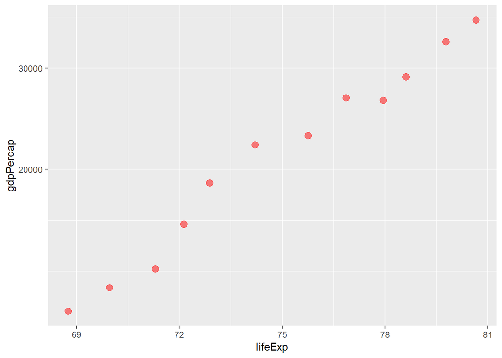

```r
gapminder %>%
  filter(country == "Canada") %>%
  ggplot() +
  aes(x= lifeExp, y= gdpPercap) +
  geom_point(fill = "red", color = "red", alpha = .5, size = 3) +
  scale_y_continuous(trans = "log10")
```

# Excercise 2

## 2.1

Pick two quantitative variables to explore.

Make a summary table of descriptive statistics for these variables using summarize(). Include whatever staistics you feel appropriate (mean, median sd, range, etc.). Make a scatterplot of these variables using ggplot().

```r
library(palmerpenguins)
palmerpenguins::penguins %>%
  summarize(across(c(body_mass_g, flipper_length_mm),
  list(mean = ~ mean(.x, na.rm = TRUE),
       sd = ~ sd(.x, na.rm = TRUE),
       min = ~ min(.x, na.rm = TRUE),
       max = ~ max(.x, na.rm = TRUE))))
```

```
## # A tibble: 1 x 8
##   body_mass_g_mean body_mass_g_sd body_mass_g_min body_mass_g_max
##              <dbl>          <dbl>           <int>           <int>
## 1            4202.           802.            2700            6300
## # ... with 4 more variables: flipper_length_mm_mean <dbl>,
## #   flipper_length_mm_sd <dbl>, flipper_length_mm_min <int>,
## #   flipper_length_mm_max <int>
```

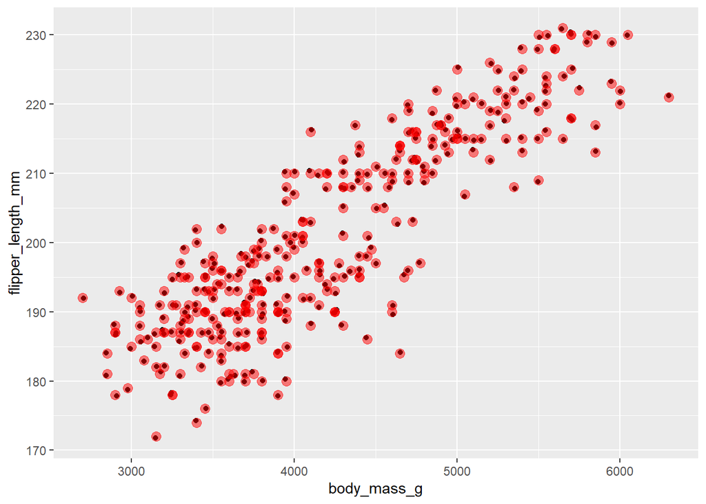

```r
palmerpenguins::penguins %>%
  ggplot() +
  aes(x = body_mass_g, y = flipper_length_mm) +
  geom_jitter() +
  geom_point(fill = "white", color = "red", alpha = .5,  size = 3)
```

## 2.2

Pick one categorical variable and one quantitative variable to explore.

Make a summary table giving the sample size (hint: n()) and descriptive statistics for the quantitative variable by group. Make one or more useful plots to visualize these variables.

```r
palmerpenguins::penguins %>%
  group_by(species) %>%
  summarize(
    total_penguins = n(),
    average_body_mass = mean(body_mass_g, na.rm = TRUE),
    sd_of_body_mass = sd(body_mass_g, na.rm = TRUE),
    average_flipper_length = mean(flipper_length_mm, na.rm = TRUE),
    sd_of_flipper_length = sd(flipper_length_mm, na.rm = TRUE))
```

```
## # A tibble: 3 x 6
##   species total_penguins average_body_ma~ sd_of_body_mass average_flipper~
## * <fct>            <int>            <dbl>           <dbl>            <dbl>
## 1 Adelie             152            3701.            459.             190.
## 2 Chinst~             68            3733.            384.             196.
## 3 Gentoo             124            5076.            504.             217.
## # ... with 1 more variable: sd_of_flipper_length <dbl>
```

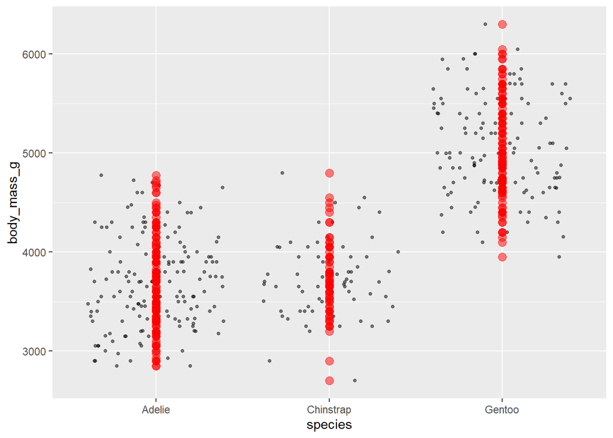

```r
palmerpenguins::penguins %>%
  ggplot() +
  geom_jitter(height = 1.5,
              alpha = .5,
              size = 1.0) +
  aes(x = species, y = body_mass_g) +
  geom_point(fill = "black", color = "red", alpha = .5, size = 3)
```

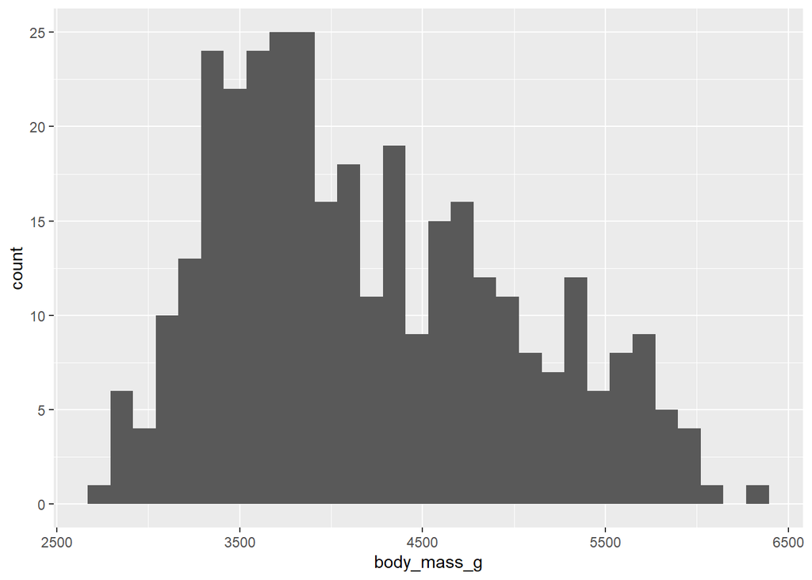

```r
palmerpenguins::penguins %>%
  ggplot() +
  aes(body_mass_g) +
  geom_histogram()
```